# DV_Project3

Panyu Peng - pp9774 & Bryan Ho - bth679

October 16, 2015

# Before loading the datas from Oracle, We are going to source these packages below

```r
require("jsonlite")
require("RCurl")
require("dplyr")
```

```r
require("ggplot2")
require("knitr")
require("dplyr")
require("extrafont")
```

# Now, we are getting the CVS data from oracle. The data is about the Baltimore’s employees salaries in 2014.

# Also, we are going to provide the summary and subset of this data

```r
# Change the USER and PASS below to be your UTEid
baltimore <- data.frame(fromJSON(getURL(URLencode('129.152.144.84:5001/rest/native/?query="select * from BALTIMORE_EMPLOYEE_SALARIES14"'),httpheader=c(DB='jdbc:oracle:thin:@129.152.144.84:1521/PDBF15DV.usuniversi01134.oraclecloud.internal', USER='cs329e_bth679', PASS='orcl_bth679', MODE='native_mode', MODEL='model', returnDimensions = 'False', returnFor = 'JSON'), verbose = TRUE), ))
summary(baltimore)
```

```
##                FULL_NAME                         POSITION_TITLE
##  Alexander,Jennifer :    2   AIDE BLUE CHIP             : 4817
##  Amatus-Salaam,Aasya:    2   POLICE OFFICER             : 1866
##  Atikpoh,Sochima S  :    2   LABORER (Hourly)           :  597
##  Bailey,Damon M     :    2   EMT Firefighter Suppression:  358
##  Banks,Joseph A     :    2   CROSSING GUARD             :  337
##  Basilio,Joan R     :    2   COMMUNITY AIDE             :  302
##  (Other)            :18969   (Other)                    :10704
##     AGENCYID                         DEPARTMENT_NAME    HIREDATE
##  P04001 :  316   Youth Summer                :4323   5/21/14: 1478
##  C90786 :  276   Police Department           :3211   6/10/13:  696
##  W02629 :  193   Fire Department             :1576   6/12/12:  541
##  P04002 :  191   DPW-Water  and  Waste Water :1491   6/7/11 :  368
##  A99416 :  166   HLTH-Health Department      : 833   5/29/14:  347
##  A50209 :  125   TRANS-Highways              : 652   6/3/10 :  192
##  (Other):17714   (Other)                     :6895   (Other):15359
##  CURRENT_ANNUAL_SALARY X2014_GROSS_PAY_RECEIVED
##  Min.   :     0        null   : 3223
##  1st Qu.: 11310        1051.25:  848
##  Median : 36400        1015   :  169
##  Mean   : 39757        0      :  139
##  3rd Qu.: 60598        870    :   80
##  Max.   :238772        978.75 :   67
##                        (Other):14455
```

```r
head(baltimore)
```

```
##                    FULL_NAME               POSITION_TITLE AGENCYID
## 1  Alderman-McCauley,Ebony N SOCIAL PROG ADMINISTRATOR II   A65072
## 2         Aldujaili,Muataz N               AIDE BLUE CHIP   W02633
## 3              Alenga,Mkwala               AIDE BLUE CHIP   W02543
## 4               Alenga,Mussa               AIDE BLUE CHIP   W02543
## 5           Alessi,Michael J              POLICE SERGEANT   A99002
## 6 Alexander Brooks,Breyona L               AIDE BLUE CHIP   W02337
##           DEPARTMENT_NAME HIREDATE CURRENT_ANNUAL_SALARY
## 1 HLTH-Health Department    4/2/14                 47600
## 2           Youth Summer   5/21/14                 11310
## 3          Youth Summer    5/29/14                 11310
## 4          Youth Summer    5/21/14                 11310
## 5      Police Department   6/20/96                 77825
## 6          Youth Summer     6/5/14                 11310
##   X2014_GROSS_PAY_RECEIVED
## 1         10251.9501953125
## 2                     null
## 3                     null
## 4                     null
## 5             76207.640625
## 6                     null
```

# And next, we are getting the data of Florida’s employees salaries in 2014 from oracle. This data has already been used from the previous project.

# However, we are still going to provide the summary and subset of this data.

```r
florida <- data.frame(fromJSON(getURL(URLencode('129.152.144.84:5001/rest/native/?query="select * from EMPLOYEE_SALARIES_20142"'),httpheader=c(DB='jdbc:oracle:thin:@129.152.144.84:1521/PDBF15DV.usuniversi01134.oraclecloud.internal', USER='cs329e_bth679', PASS='orcl_bth679', MODE='native_mode', MODEL='model', returnDimensions = 'False', returnFor = 'JSON'), verbose = TRUE), ))
summary(florida)
```

```
##              FULL_NAME    GENDER     DEPARTMENT
##  Carter, Jerome   :   2   F:3713   POL    :1840
##  Cruz, Angela     :   2   M:5387   HHS    :1550
##  Aarhus, Pam J    :   1            FRS    :1309
##  Aaron, David J   :   1            DOT    :1186
##  Aaron, Marsha M  :   1            COR    : 499
##  Ababio, Godfred A:   1            DGS    : 430
##  (Other)          :9092            (Other):2286
##                                 DEPARTMENT_NAME
##  Department of Police                   :1840
##  Department of Health and Human Services:1550
##  Fire and Rescue Services               :1309
##  Department of Transportation           :1186
##  Correction and Rehabilitation          : 499
##  Department of General Services         : 430
##  (Other)                                :2286
##                                        DIVISION
##  School Health Services                    : 297
##  Transit Silver Spring Ride On             : 277
##  Transit Gaithersburg Ride On              : 273
##  Highway Services                          : 217
##  Child Welfare Services                    : 199
##  FSB Traffic Division School Safety Section: 166
##  (Other)                                   :7671
##        ASSIGNMENT_CATEGORY                             POSITION_TITLE
##  Fulltime-Regular:8244     Police Officer III                 : 886
##  Parttime-Regular: 856     Firefighter/Rescuer III            : 697
##                            Bus Operator                       : 606
##                            Manager III                        : 245
##                            Correctional Officer III (Corporal): 234
##                            Office Services Coordinator        : 218
##                            (Other)                            :6214
##                      UNDERFILLED_JOB_TITLE DATE_FIRST_HIRED
##  null                           :7982      1/14/13:  90
##  Firefighter/Rescuer II         : 255      2/24/14:  77
##  Police Officer I               : 188      3/10/14:  72
##  Firefighter/Rescuer I (Recruit): 111      9/22/14:  70
##  Correctional Officer II (PFC)  :  64      10/6/14:  66
##  Police Officer II              :  54      8/12/13:  63
##  (Other)                        : 446      (Other):8662
##  CURRENT_ANNUAL_SALARY X2014_GROSS_PAY_RECEIVED
##  Min.   :  7200        Min.   :     0
##  1st Qu.: 49418        1st Qu.: 51383
##  Median : 65561        Median : 71217
##  Mean   : 69843        Mean   : 73362
##  3rd Qu.: 87425        3rd Qu.: 94023
##  Max.   :294263        Max.   :298023
##
##            X2014_OVERTIME_PAY
##  null               :2893
##  26.4099998474121   :  16
##  0.00999999977648258:  14
##  67.0500030517578   :   9
##  58.4300003051758   :   7
##  13.8100004196167   :   6
##  (Other)            :6155
```

```r
head(florida)
```

```
##           FULL_NAME GENDER DEPARTMENT
## 1 Addison, Steven J      M        DOT
## 2   Addo, Robert K.      M        DLC
## 3     Addy, Maame A      F        HHS
## 4     Adebayo, Ruth      F        DLC
## 5    Adegun, Yisa F      M        DOT
## 6  Ade, Priscilla N      F        HHS
##                           DEPARTMENT_NAME
## 1            Department of Transportation
## 2            Department of Liquor Control
## 3 Department of Health and Human Services
## 4            Department of Liquor Control
## 5            Department of Transportation
## 6 Department of Health and Human Services
##                                       DIVISION ASSIGNMENT_CATEGORY
```

[output cut: 27 more lines]

# Inner Join & Its Data Wrangling

```r
source("../03 Visualizations/innerJoin.R", echo = TRUE)
```

```
##
## > df <- data.frame(dplyr::inner_join(baltimore, florida,
## +     by = "CURRENT_ANNUAL_SALARY"))
##
## > df %>% select(POSITION_TITLE.y, CURRENT_ANNUAL_SALARY,
## +     GENDER) %>% ggplot(aes(x = POSITION_TITLE.y, y = CURRENT_ANNUAL_SALARY,
## +     color = .... [TRUNCATED]
```

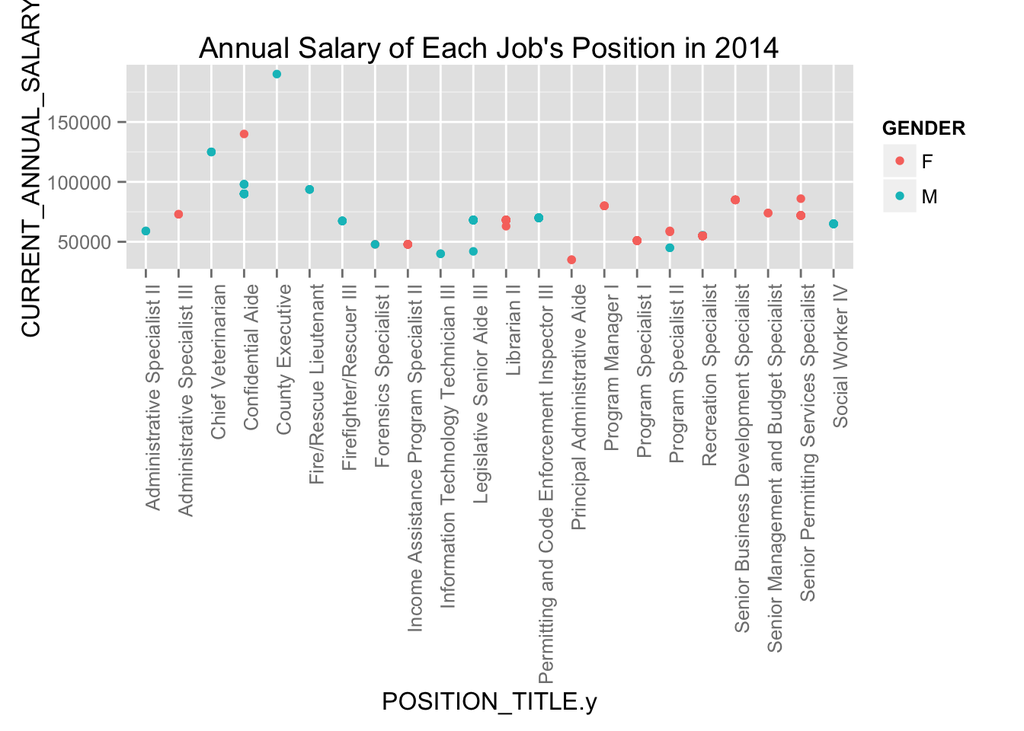

## Observations:

### From this plot, we see that the job position that got the highest annual salary in 2014 was County Executive, which was approximately equal to $190,000. We also know that the Principal Administrative Aide position got the lowest annual salary. Overall, the average of annual salary that all jobs positions was about $65,000 to $70,000 and slightly differences between female and male, but nothing significant.

# Outer Join & Its Data Wrangling

```r
source("../03 Visualizations/outerJoin.R", echo = TRUE)
```

```
##
## > df1 <- data.frame(dplyr::full_join(florida, baltimore,
## +     by = "CURRENT_ANNUAL_SALARY"))
##
## > df1 %>% select(DEPARTMENT_NAME.x, GENDER, HIREDATE) %>%
## +     arrange(HIREDATE) %>% ggplot(aes(x = DEPARTMENT_NAME.x, y = as.character(as.numeric(H .... [TRUNCATED]
```

[figure not shown]

# Combining data sets and its data wrangling

```r
source("../03 Visualizations/combineData.R", echo = TRUE)
```

```
##
## > df2 <- data.frame(dplyr::bind_cols(florida, sample_n(baltimore,
## +     9100)))
##
## > df2 %>% select(DEPARTMENT, GENDER) %>% filter(DEPARTMENT %in%
## +     c("POL", "HHS")) %>% ggplot(aes(x = DEPARTMENT)) + geom_bar() +
## +     facet_gr .... [TRUNCATED]
```

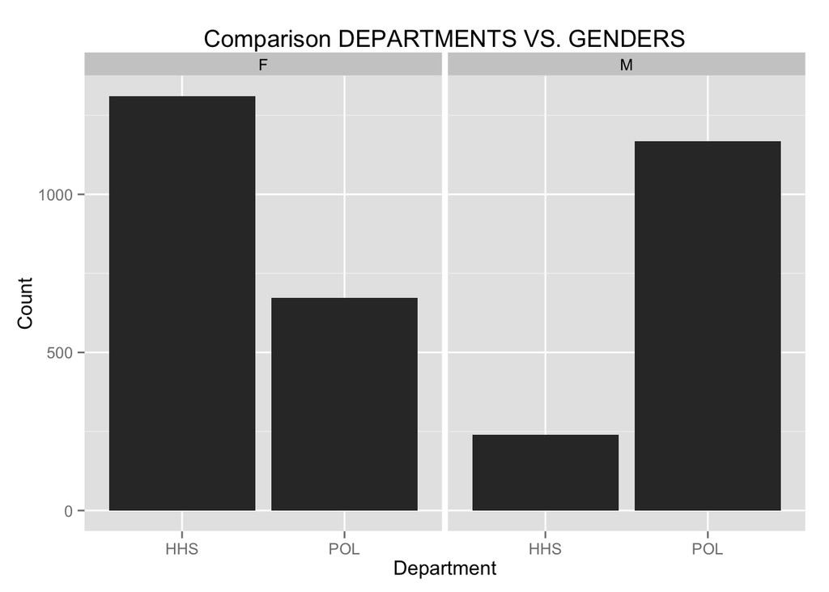

## Observation:

### According to this plot, we can see that the department of health and human services tends to have more female than the department of police. And there are more male in department of police than the department of health and human services. It does makes sense to see this result because most of police’s jobs are dangerous, so male fits better for these position. In the other hand, female can takes care for others better than male. So, this plot does give us a very accurate observation that we hoped for.